# Lab Assignment One: Exploring Table Data

Ryan Schaefer

```python
from numba.core.errors import NumbaDeprecationWarning
import warnings
warnings.simplefilter('ignore', NumbaDeprecationWarning)
```

```python
import pandas as pd
import numpy as np
import matplotlib.pyplot as plt
import seaborn as sns
import missingno as mn
from sklearn.impute import KNNImputer
from sklearn.preprocessing import StandardScaler
import copy
import umap
```

# Business Understanding

This data set contains records about over 16,000 video games released in 2016 or earlier. The data includes attributes with basic facts about the game (year of release, genre, etc), sales data in different parts of the world, and review data. The data was collected via a web scraper from two different sources: VGChartz for the basic facts and sales data, and Metacritic for the review data. This data can be used to predict how many copies of a game will be sold based on the type of game and its reviews. The problem with this data set is that the review data is lagged, meaning that it is released after or shortly before a game is launched, meaning that predictions from it are not helpful to the developer. However, video games go through a rigorous testing process, in which external testers are brought in during the beta testing stage (1). These beta testers generally represent the intended target audience, but can also include content creators and reviewers. Through the testing process, studios can get feedback and early reviews for their games while they are in early development. Such a data set is not publically available, but it would most likely be similar in structure to the data used in this notebook. This data set will be used to simulate early feedback reviews that a studio would generate through beta testers. If a game receives negative enough feedback from beta testers, the development of the game may be cancelled so that the studio can move on to other projects, like what happened to *Star Wars: Attack Squadrons* in 2014 (2). A prediction of how many sales a game will make based on early reviews and the type of game can help a studio determine if it is worth continuing production of a game. To be a useful prediction, a model would need to be able to, more often that not, accurately predict whether or not the game will generate enough sales to make finishing the development process worthwhile.

Link to dataset:

- https://www.kaggle.com/datasets/rush4ratio/video-game-sales-with-ratings

Other sources:

1. https://kevurugames.com/blog/main-stages-of-video-game-testing-from-concept-to-perfection
2. https://www.dualshockers.com/new-star-wars-game-cancelled-right-after-beta-testing/

# Load Data

```python
# Load raw data from csv file
df = pd.read_csv("../../Datasets/video_game_sales.csv")

df.head()
```

|  | Name | Platform | Year_of_Release | Genre | Publisher | NA_Sales | EU_Sales | JP_Sales | Other_Sales | Global_Sales | Critic_Score | Critic_Count | User_Score | User_Count | Developer | Rating |
| --- | --- | --- | --- | --- | --- | --- | --- | --- | --- | --- | --- | --- | --- | --- | --- | --- |
| 0 | Wii Sports | Wii | 2006.0 | Sports | Nintendo | 41.36 | 28.96 | 3.77 | 8.45 | 82.53 | 76.0 | 51.0 | 8 | 322.0 | Nintendo | E |
| 1 | Super Mario Bros. | NES | 1985.0 | Platform | Nintendo | 29.08 | 3.58 | 6.81 | 0.77 | 40.24 | NaN | NaN | NaN | NaN | NaN | NaN |
| 2 | Mario Kart Wii | Wii | 2008.0 | Racing | Nintendo | 15.68 | 12.76 | 3.79 | 3.29 | 35.52 | 82.0 | 73.0 | 8.3 | 709.0 | Nintendo | E |
| 3 | Wii Sports Resort | Wii | 2009.0 | Sports | Nintendo | 15.61 | 10.93 | 3.28 | 2.95 | 32.77 | 80.0 | 73.0 | 8 | 192.0 | Nintendo | E |
| 4 | Pokemon Red/Pokemon Blue | GB | 1996.0 | Role-Playing | Nintendo | 11.27 | 8.89 | 10.22 | 1.00 | 31.37 | NaN | NaN | NaN | NaN | NaN | NaN |

For prediction purposes, only global sales are needed. Thus, sales numbers from specific regions can be dropped. Additionally, the number of critics or users who reviewed a game on Metacritic is not useful if this data set is meant to be an estimate of early reviews, so those attributes can also be dropped. Finally, the name of the game only serves as a label, so it is not needed for prediction and can be dropped.

```python
# Drop unwanted columns
df = df.drop(["Name", "NA_Sales", "EU_Sales", "JP_Sales", "Other_Sales", "Critic_Count", "User_Count"], axis = 1)

df.info()
```

```
<class 'pandas.core.frame.DataFrame'>
RangeIndex: 16719 entries, 0 to 16718
Data columns (total 9 columns):
 #   Column           Non-Null Count  Dtype
---  ------           --------------  -----
 0   Platform         16719 non-null  object
 1   Year_of_Release  16450 non-null  float64
 2   Genre            16717 non-null  object
 3   Publisher        16665 non-null  object
 4   Global_Sales     16719 non-null  float64
 5   Critic_Score     8137 non-null   float64
 6   User_Score       10015 non-null  object
 7   Developer        10096 non-null  object
 8   Rating           9950 non-null   object
dtypes: float64(3), object(6)
memory usage: 1.1+ MB
```

# Clean Data

Based on the data types assigned to each column, the only one that does not seem right is the user score. The user score should be numeric, not an object, so let's see what non-numeric values are in this column.

```python
# Find any non-numeric values in the user score column (max possible user score is 9.9)
df[df["User_Score"] > "9.9"]["User_Score"].value_counts()
```

```
tbd    2425
Name: User_Score, dtype: int64
```

2,425 records have a user score of "tbd", which is not useful for analysis, so these records can be dropped.

```python
# Drop tbd values from the user score column
df = df[df["User_Score"] != "tbd"]
```

```
Number of records with missing values: 7469
Number of records after dropping missing values: 6825
```

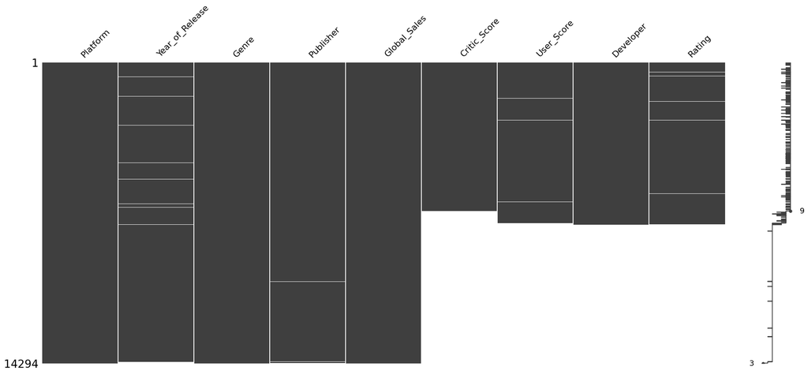

```python
%matplotlib inline

# Visualize missing data
mn.matrix(df.sort_values(["Critic_Score", "User_Score", "Developer", "Rating", "Year_of_Release", "Publisher"]))

# Print the number of records with and without missing data
print("Number of records with missing values:", len(df) - len(df.dropna()))
print("Number of records after dropping missing values:", len(df.dropna()))
```

Based on the plot above, there are a significant number of records missing critic score, user score, developer, and rating data. This missing values exist, because the data for these games was found on VGChartz but not Metacritic. There are also some other records that are missing data in some columns. If all records with any missing data are dropped, there are still 6,825 records remaining, which should be enough data to detect any patterns useful for prediction.

```python
# Drop records with missing values
df = df.dropna().reset_index(drop = True)
# Convert the user score to a numeric column after removing 'tbd' and missing values
df["User_Score"] = pd.to_numeric(df["User_Score"])
# Convert year of release column to integer (ordinal feature)
df["Year_of_Release"] = df["Year_of_Release"].astype(int)
df.head()
```

|  | Platform | Year_of_Release | Genre | Publisher | Global_Sales | Critic_Score | User_Score | Developer | Rating |
| --- | --- | --- | --- | --- | --- | --- | --- | --- | --- |
| 0 | Wii | 2006 | Sports | Nintendo | 82.53 | 76.0 | 8.0 | Nintendo | E |
| 1 | Wii | 2008 | Racing | Nintendo | 35.52 | 82.0 | 8.3 | Nintendo | E |
| 2 | Wii | 2009 | Sports | Nintendo | 32.77 | 80.0 | 8.0 | Nintendo | E |
| 3 | DS | 2006 | Platform | Nintendo | 29.80 | 89.0 | 8.5 | Nintendo | E |
| 4 | Wii | 2006 | Misc | Nintendo | 28.92 | 58.0 | 6.6 | Nintendo | E |

```python
df.info()
```

```
<class 'pandas.core.frame.DataFrame'>
RangeIndex: 6825 entries, 0 to 6824
Data columns (total 9 columns):
 #   Column           Non-Null Count  Dtype
---  ------           --------------  -----
 0   Platform         6825 non-null   object
 1   Year_of_Release  6825 non-null   int64
 2   Genre            6825 non-null   object
 3   Publisher        6825 non-null   object
 4   Global_Sales     6825 non-null   float64
 5   Critic_Score     6825 non-null   float64
 6   User_Score       6825 non-null   float64
 7   Developer        6825 non-null   object
 8   Rating           6825 non-null   object
dtypes: float64(3), int64(1), object(5)
memory usage: 480.0+ KB
```

```python
df.describe()
```

|  | Year_of_Release | Global_Sales | Critic_Score | User_Score |
| --- | --- | --- | --- | --- |
| count | 6825.000000 | 6825.000000 | 6825.000000 | 6825.000000 |
| mean | 2007.436777 | 0.777590 | 70.272088 | 7.185626 |
| std | 4.211248 | 1.963443 | 13.868572 | 1.439942 |
| min | 1985.000000 | 0.010000 | 13.000000 | 0.500000 |
| 25% | 2004.000000 | 0.110000 | 62.000000 | 6.500000 |
| 50% | 2007.000000 | 0.290000 | 72.000000 | 7.500000 |
| 75% | 2011.000000 | 0.750000 | 80.000000 | 8.200000 |
| max | 2016.000000 | 82.530000 | 98.000000 | 9.600000 |

Using the description of the numeric columns in this data set, a few observations can be made about the shape of the data:

- The minimum year of release is approximately 5 standard deviations less than the mean and the mean is approximately equal to the median. This suggests that the distribution is approximately symmetrical, but there are outliers on the lower end. This will be investigated numerically prior to the data visualization.
- The maximum global sales is much larger than the 75th percentile and the mean is significantly larger than the median. This suggests that the distribution is right skewed and there are some outliers that are much larger than the rest of the distribution.
- All metrics for the critic score are very similar to the corresponding metric for the user score. The main difference is that the critic score is on a 100 point scale and the user score is on a 10 point scale. This suggests that the distributions of these columns may be similar.

```python
# Find the frequency of each year of release
df["Year_of_Release"].value_counts().sort_index()
```

```
1985      1
1988      1
1992      1
1994      1
1996      7
1997     13
1998     25
1999     30
2000    102
2001    256
2002    455
2003    498
2004    476
2005    562
2006    528
2007    590
2008    592
2009    550
2010    429
2011    453
2012    313
2013    266
2014    253
2015    211
2016    212
Name: Year_of_Release, dtype: int64
```

The record counts by year of release above show that there are several years missing prior to 2000, and that relatively few records exist for the years prior to 2000 that are represented. To ensure that the data is more evenly distributed across time, all records with a year of release less than 2000 will be dropped.

```python
# Remove records where the year of release is less than 2000
df = df[df["Year_of_Release"] >= 2000].reset_index(drop = True)

df.describe()
```

|  | Year_of_Release | Global_Sales | Critic_Score | User_Score |
| --- | --- | --- | --- | --- |
| count | 6746.000000 | 6746.000000 | 6746.000000 | 6746.000000 |
| mean | 2007.551734 | 0.764339 | 70.131930 | 7.172161 |
| std | 4.091946 | 1.951595 | 13.829731 | 1.438398 |
| min | 2000.000000 | 0.010000 | 13.000000 | 0.500000 |
| 25% | 2004.000000 | 0.110000 | 62.000000 | 6.500000 |
| 50% | 2007.000000 | 0.290000 | 72.000000 | 7.500000 |
| 75% | 2011.000000 | 0.740000 | 80.000000 | 8.200000 |
| max | 2016.000000 | 82.530000 | 98.000000 | 9.600000 |

```python
dups = df.duplicated()

len(df[dups])
```

```
0
```

This data set contains no duplicate records.

## Relevant Variables

```python
# Allow text to wrap to avoid cutting off descriptions
pd.set_option('display.max_colwidth', 0)

# Create data frame with feature descriptions
pd.DataFrame({
    "Feature": df.columns,
    "Description": [
        "The gaming platform/console a game was released on",
        "The year a game was released",
        "The genre of a game",
        "The publisher that released a game",
        "The number of global sales a game generated on this platform in millions of copies",
        "The average critic Metacritic score for a game",
        "The average user Metacritic score for a game",
        "The developer that created a game",
        "The ESRB rating for a game"
    ],
    "Scale": [
        "Nominal",
        "Interval",
        "Nominal",
        "Nominal",
        "Ratio",
        "Ratio",
        "Ratio",
        "Nominal",
        "Nominal"
    ],
    "Discrete/Continuous": [
        "Discrete",
        "Continuous",
        "Discrete",
        "Discrete",
        "Continuous",
        "Continuous",
        "Continuous",
        "Discrete",
        "Discrete"
    ],
    "Range": [
        repr(set(df["Platform"])),
        "2000 - 2016",
        repr(set(df["Genre"])),
        # Only print values from first 20 records to avoid clutter
        repr(set(df["Publisher"][0:20])),
        "0.01 - 82.53",
        "13 - 98",
        "0.5 - 9.6",
        # Only print values from first 20 records to avoid clutter
        repr(set(df["Developer"][0:20])),
        repr(set(df["Rating"]))
    ]
})
```

|  | Feature | Description | Scale | Discrete/Continuous | Range |
| --- | --- | --- | --- | --- | --- |
| 0 | Platform | The gaming platform/console a game was released on | Nominal | Discrete | {'GBA', 'PC', 'PS', 'Wii', 'PS2', 'PS4', 'XOne', 'X360', 'DS', 'WiiU', 'GC', 'XB', '3DS', 'DC', 'PS3', 'PSP', 'PSV'} |
| 1 | Year_of_Release | The year a game was released | Interval | Continuous | 2000 - 2016 |
| 2 | Genre | The genre of a game | Nominal | Discrete | {'Strategy', 'Role-Playing', 'Puzzle', 'Misc', 'Racing', 'Simulation', 'Adventure', 'Shooter', 'Fighting', 'Sports', 'Action', 'Platform'} |
| 3 | Publisher | The publisher that released a game | Nominal | Discrete | {'Nintendo', 'Microsoft Game Studios', 'Take-Two Interactive', 'Sony Computer Entertainment', 'Activision'} |
| 4 | Global_Sales | The number of global sales a game generated on this platform in millions of copies | Ratio | Continuous | 0.01 - 82.53 |
| 5 | Critic_Score | The average critic Metacritic score for a game | Ratio | Continuous | 13 - 98 |
| 6 | User_Score | The average user Metacritic score for a game | Ratio | Continuous | 0.5 - 9.6 |
| 7 | Developer | The developer that created a game | Nominal | Discrete | {'Nintendo', 'Treyarch', 'Rockstar North', 'Good Science Studio', 'Infinity Ward, Sledgehammer Games', 'Polyphony Digital'} |
| 8 | Rating | The ESRB rating for a game | Nominal | Discrete | {'E10+', 'T', 'AO', 'RP', 'M', 'E'} |

# Data Visualization

## Feature Distributions

### Response Variable

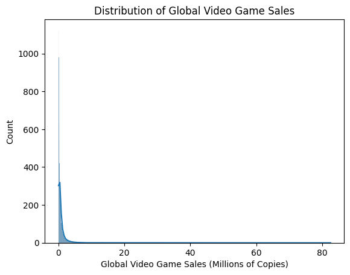

```python
sns.histplot(x = df["Global_Sales"], kde = True)

plt.title("Distribution of Global Video Game Sales")
plt.xlabel("Global Video Game Sales (Millions of Copies)")

plt.show()
```

As predicted based on the data description, the histogram of the global sales shows that there are outliers that are much larger than the majority of the distribution. This makes it difficult to view the shape of the distribution from this plot, so a histogram of the global sales of less than 5 million copies will help make the histogram easier to read.

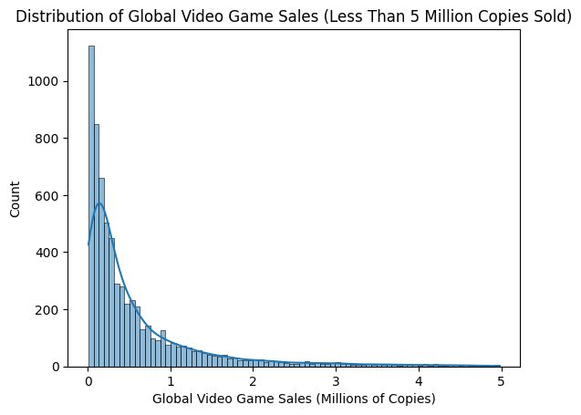

```python
# Filter data where global sales is less than 5 million copies
sns.histplot(x = df[df["Global_Sales"] < 5]["Global_Sales"], kde = True)

plt.title("Distribution of Global Video Game Sales (Less Than 5 Million Copies Sold)")
plt.xlabel("Global Video Game Sales (Millions of Copies)")

plt.show()
```

Based on the zoomed in histogram of the global sales, the distribution is right skewed, with the majority of games generating fewer than 1 million sales.

### Categorical Features

Before plotting the categorical features of this data set, it can be useful to view how many unique values exist for each feature.

```python
df[["Platform", "Genre", "Publisher", "Developer", "Rating"]].nunique().sort_values()
```

```
Rating       6
Genre        12
Platform     17
Publisher    252
Developer    1283
dtype: int64
```

The data above shows that the publisher and developer columns have far too many unique values to show on one plot, so the 10 most frequent values will be used to get an idea of what the data looks like.

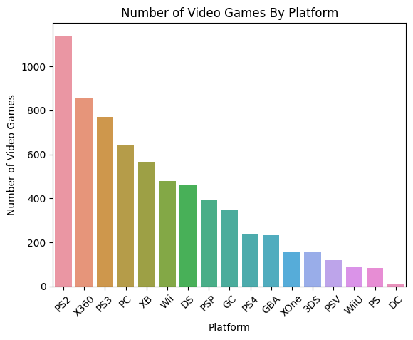

```python
sns.countplot(x = "Platform", data = df, order = df["Platform"].value_counts().index)

plt.title("Number of Video Games By Platform")
plt.xlabel("Platform")
plt.ylabel("Number of Video Games")
plt.xticks(rotation = 45)

plt.show()
```

The bar plot of the number of games by platform show that major brands like Playstation and Xbox have the most games. Newer consoles from those brands, like the PS4 and Xbox One, have far fewer games that the older consoles, but would likely catch up over time. The console with the fewest games is DC (Sega Dreamcast), which was released in 1998 in Japan and discontinued in 2001 ([Wikipedia](https://en.wikipedia.org/wiki/Dreamcast#:~:text=The%20Dreamcast%20is%20a%20home,%2C%20and%20Microsoft's%20Xbox.)).

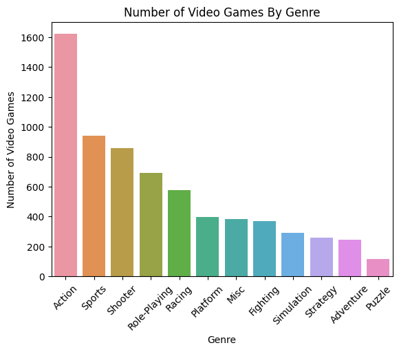

```python
# Sort by genre frequency
sns.countplot(x = "Genre", data = df, order = df["Genre"].value_counts().index)

plt.title("Number of Video Games By Genre")
plt.xlabel("Genre")
plt.ylabel("Number of Video Games")
plt.xticks(rotation = 45)

plt.show()
```

The bar plot of the number of games by genre shows that there are far more action games than any other genre and that there are fewer puzzle games than any other genre.

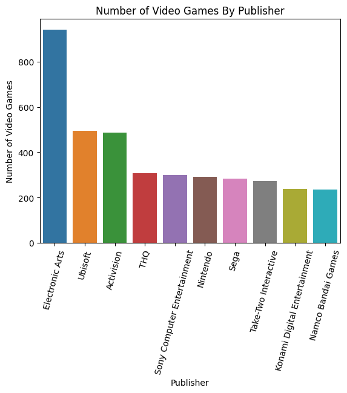

```python
# Filter for only 10 most frequent publishers
top_publishers = df["Publisher"].value_counts().index[0:10]
df_pub = df[df["Publisher"].isin(top_publishers)]

sns.countplot(x = "Publisher", data = df_pub, order = top_publishers)

plt.title("Number of Video Games By Publisher")
plt.xlabel("Publisher")
plt.ylabel("Number of Video Games")
plt.xticks(rotation = 75)

plt.show()
```

As there are 252 different publishers in this data set, the bar plot of the number of video games by publisher only shows the 10 most frequent publishers. The plot shows that Electronic Arts have released the most games by a significant margin. Other major publishers, like Ubisoft and Activision, are also among publishers who have released the most games.

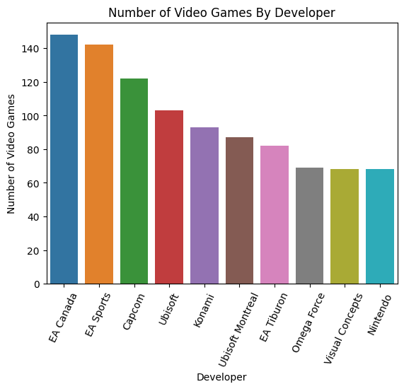

```python
# Filter for only 10 most frequent developers
top_developers = df["Developer"].value_counts().index[0:10]
df_dev = df[df["Developer"].isin(top_developers)]

sns.countplot(x = "Developer", data = df_dev, order = top_developers)

plt.title("Number of Video Games By Developer")
plt.xlabel("Developer")
plt.ylabel("Number of Video Games")
plt.xticks(rotation = 65)

plt.show()
```

As there are 1,283 different developers in this data set, the bar plot of the number of video games by developer only shows the 10 most frequent developers. The plot shows that two subsidiaries of Electronic Arts, EA Canada and EA Sports, are the two developers with the most games. Another Electronic Arts subsidiary, EA Tiburon, also features in the 10 most frequent developers. Since there are 3 subsidiaries of Electronic Arts in the most frequent developers, it makes sense that Electronic Arts are also the most frequent publisher (previous bar plot).

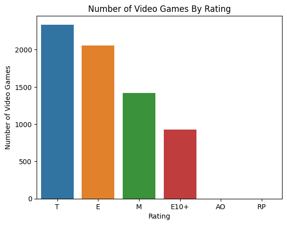

```python
# Sort by rating frequency
sns.countplot(x = "Rating", data = df, order = df["Rating"].value_counts().index)

plt.title("Number of Video Games By Rating")
plt.xlabel("Rating")
plt.ylabel("Number of Video Games")

plt.show()
```

The bar plot of the number of video games by rating shows that T (Teen) and E (Everyone) are the most common ratings.

Many action and shooter games (2 of the 3 most common genres based on the earlier bar plot) are likely to have a T rating, as the violence is too much for an E rating. Additionally, many developers will try not to make the violence too extreme to keep the T rating and appeal to a larger audience than an M (Mature) rated game.

Many sports games (2nd most common genre) are likely to have an E rating, because there is minimal violence or other things too extreme for young children involved in most sports. Additionally, any games designed for children or families are likely to have an E rating.

The strange thing about this bar plot is that there are games with a rating of AO or RP, but there are so few that the bar is not visible. We can filter the data set to just these two ratings to get a closer look.

```python
# Filter data for records with an ESRB rating of AO or RP
df[df["Rating"].isin(["AO", "RP"])]
```

|  | Platform | Year_of_Release | Genre | Publisher | Global_Sales | Critic_Score | User_Score | Developer | Rating |
| --- | --- | --- | --- | --- | --- | --- | --- | --- | --- |
| 557 | XB | 2005 | Action | Take-Two Interactive | 1.95 | 93.0 | 8.6 | Rockstar North | AO |
| 6296 | PC | 2011 | Strategy | Paradox Interactive | 0.03 | 63.0 | 6.8 | BattleGoat Studios | RP |

There is only one game rated AO (Adults Only) and one game rated RP (Rating Pending) in this data set.

According to the [ESRB (Entertainment Software Rating Board) website](https://www.esrb.org/ratings-guide/), a rating of RP is only assigned to a game that is being advertised but has not received an official rating yet. The RP rating should be replaced once an official rating is assigned, but that did not happen for this one game.

According to [The Gamer](https://www.thegamer.com/video-game-ratings-grown/), only 27 games have ever been assigned an AO rating. For a game to receive an AO rating, the content must be incredibly extreme. The majority of games with adult oriented content will end up with a M rating. I assume that the remaining AO rated games had missing data and were dropped from the data set.

### Numeric Features

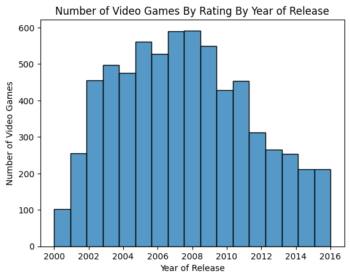

```python
# Calculate number of bins to have 1 bin per year
bins = max(df["Year_of_Release"]) - min(df["Year_of_Release"]) + 1
sns.histplot(x = "Year_of_Release", data = df, bins = bins)

plt.title("Number of Video Games By Rating By Year of Release")
plt.xlabel("Year of Release")
plt.ylabel("Number of Video Games")

plt.show()
```

The histogram of the release dates shows that the distribution is mostly symmetric. This is supported by the numeric description provided in the Data Cleaning section, which shows that the mean year of release is approximately equal to the median year of release.

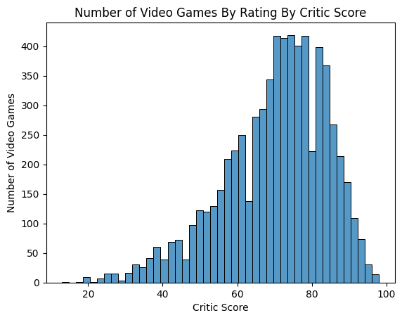

```python
sns.histplot(x = "Critic_Score", data = df)

plt.title("Number of Video Games By Rating By Critic Score")
plt.xlabel("Critic Score")
plt.ylabel("Number of Video Games")

plt.show()
```

The histogram of the critic scores shows that the distribution is left skewed. There is a large density of games with a critic score between 70 and 85, with only a few games rated higher than 85 and lots of games with ratings spread between 0 and 70. The skewness of the distribution is supported by the numeric description provided in the Data Cleaning section, which shows that the mean critic score is less than the median critic score.

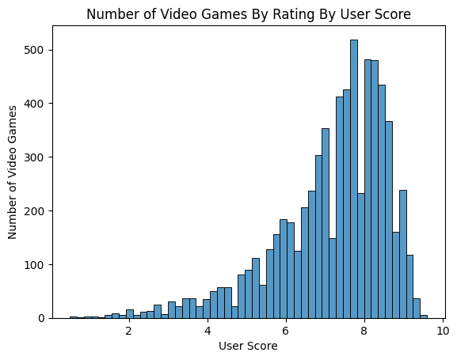

```python
sns.histplot(x = "User_Score", data = df)

plt.title("Number of Video Games By Rating By User Score")
plt.xlabel("User Score")
plt.ylabel("Number of Video Games")

plt.show()
```

The histogram of the user scores shows that the distribution is left skewed. There is a large density of games with a critic score between 7 and 9, with only a few games rated higher than 9 and lots of games with ratings spread between 0 and 7. The skewness of the distribution is supported by the numeric description provided in the Data Cleaning section, which shows that the mean user score is less than the median user score. The distribution of the user scores has a very similar shape to the distribution of the critic scores.

## Interesting Questions

### Are any genres or platforms more likely to generate sales than others?

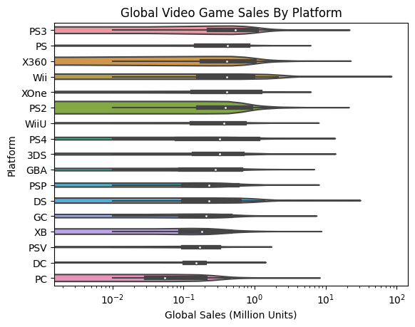

```python
# Sort platforms by median global sales
plat_medians = df.groupby("Platform").median(numeric_only = True)["Global_Sales"].sort_values(ascending = False)

sns.violinplot(x = "Global_Sales", y = "Platform", data = df, scale = "count", order = plat_medians.index)

plt.title("Global Video Game Sales By Platform")
plt.xlabel("Global Sales (Million Units)")
plt.ylabel("Platform")
plt.xscale("log")

plt.show()
```

The parallel violin plots of the global video game sales by platoform show the distributions of the global sales for each platform sorted by the median sales. The plot shows that the median global sales for most of the platforms are very similar. The platforms produced by the main console companies (PlayStation, Xbox, and Nintendo Wii) make up the top 8 platforms for median sales. The median sales on PC is significantly lower than the median sales on the other platforms, but the maximum sales is similar to that of the other platforms.

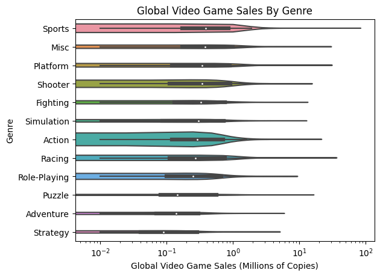

```python
# Sort genres by median global sales
genre_medians = df.groupby("Genre").median(numeric_only = True)["Global_Sales"].sort_values(ascending = False)

sns.violinplot(x = "Global_Sales", y = "Genre", data = df, scale = "count", order = genre_medians.index)

plt.title("Global Video Game Sales By Genre")
plt.xlabel("Global Video Game Sales (Millions of Copies)")
plt.ylabel("Genre")
plt.xscale("log")

plt.show()
```

The parallel violin plots of the global video game sales by genre show the distributions of the global sales for each platform sorted by the median sales. All of the genres except puzzle, adventure, and strategy have approximately the same median. Strategy games generate the least sales, but puzzle and adventure games only generate slightly more sales.

### Is the number of sales changing over time?

To determine if the number of glbal video game sales is changing over time, we should look at both the sales per game and the total sales.

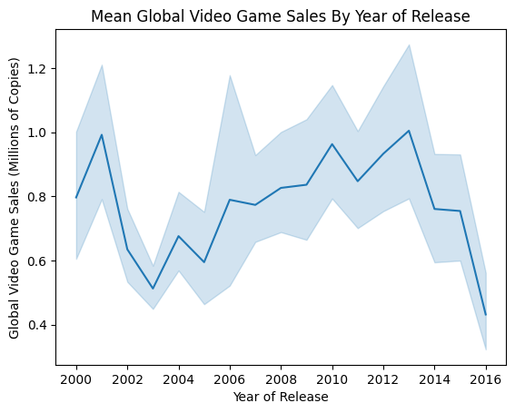

```python
sns.lineplot(x = "Year_of_Release", y = "Global_Sales", data = df)

plt.title("Mean Global Video Game Sales By Year of Release")
plt.xlabel("Year of Release")
plt.ylabel("Global Video Game Sales (Millions of Copies)")

plt.show()
```

The line plot above shows the mean global sales per game and the 95% confidence interval each year. The plot shows that there was a sharp decrease in mean sales after 2001. The mean sales gradually increased from 2003 to 2013, before sharpling declining for the rest of the time recorded in this data set.

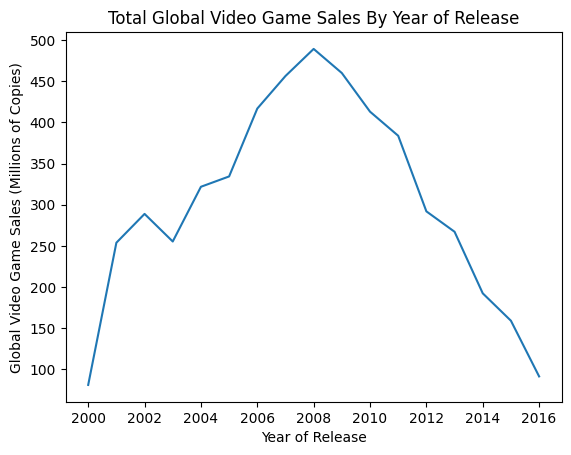

```python
# Get the total global sales for each year
df_total = df.groupby("Year_of_Release").sum(numeric_only = True).reset_index()

sns.lineplot(x = "Year_of_Release", y = "Global_Sales", data = df_total)

plt.title("Total Global Video Game Sales By Year of Release")
plt.xlabel("Year of Release")
plt.ylabel("Global Video Game Sales (Millions of Copies)")

plt.show()
```

### Are critic or user scores more correlated with global sales?

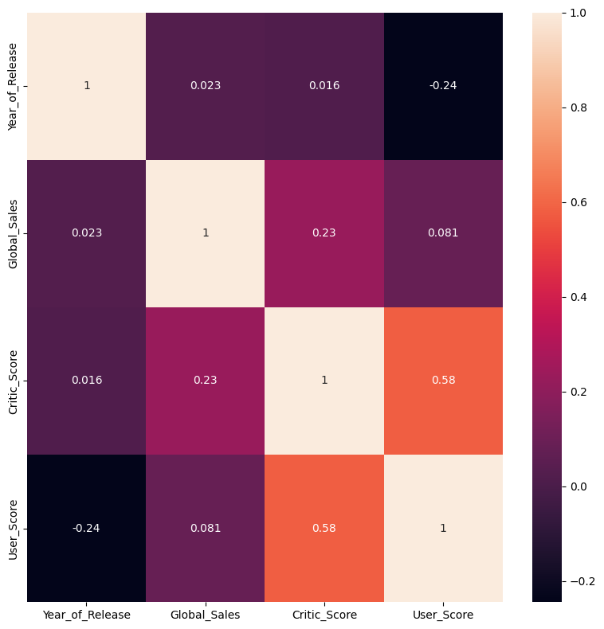

```python
# Remove all non-numeric columns
df_numeric_feature = df.select_dtypes(include='number')

f, ax = plt.subplots(figsize=(8, 8))
sns.heatmap(df_numeric_feature.corr(), annot=True)

f.tight_layout()
```

The correlation plot above shows the Pearson's correlation between each pair of quantitative features in this data set. The plot shows a few things about the correlation between variables:

- The critic score of a game is very positively correlated with the user score of that game (r = 0.58)
- The critic score of a game is more correlated with the game's global sales than the user score (r = 0.23 vs r = 0.081)
- The user score of a game is negatively correlated with the year of release (r = -0.24), suggesting that more recent games get worse use scores than older games
- There is not a significant correlation between a game's critic score and the year of release (r = 0.016)

The problem with Pearson's correlation is that it can have trouble detecting nonlinear relationships. Observing plots of the critic and user scores can help determine if this is an issue here.

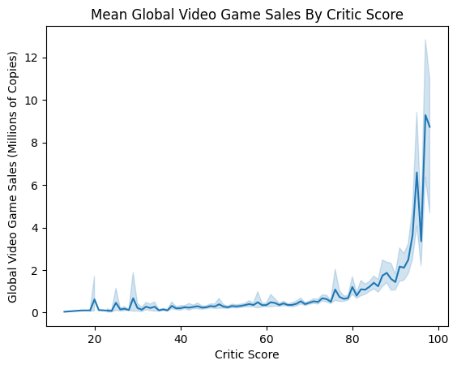

```python
sns.lineplot(x = "Critic_Score", y = "Global_Sales", data = df)

plt.title("Mean Global Video Game Sales By Critic Score")
plt.xlabel("Critic Score")
plt.ylabel("Global Video Game Sales (Millions of Copies)")

plt.show()
```

The line plot above shows the mean global sales and 95% confidence interval plotted against the critic score. The plot shows that the relationship between the mean global sales and critic score is exponential, not linear, suggesting that there may be a stronger correlation between these variables than the Pearson's correlation indicates.

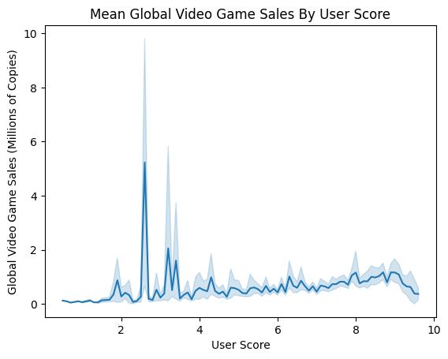

```python
sns.lineplot(x = "User_Score", y = "Global_Sales", data = df)

plt.title("Mean Global Video Game Sales By User Score")
plt.xlabel("User Score")
plt.ylabel("Global Video Game Sales (Millions of Copies)")

plt.show()
```

The line plot above shows the mean global sales and 95% confidence interval plotted against the user score. The plot shows that the relationship between the mean global sales and user score is closer to linear than the critic score, but the slope does slightly increase as the user score increases. Additionally, the mean global sales has more variablility when plotted against the user score than against the critic score. A nonlinear correlation is likely to find a stronger correlation than the Pearson's correlation, but the user score appears to be less correlated with the global sales than the critic score.

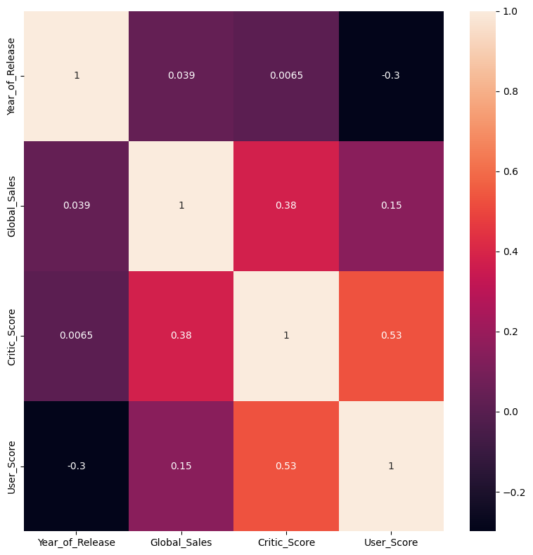

```python
f, ax = plt.subplots(figsize=(8, 8))
sns.heatmap(df_numeric_feature.corr(method = "spearman"), annot=True)

f.tight_layout()
```

The correlation plot above shows the Spearman's correlation between each pair of quantitative variables in this data set. Spearman's correlation is better at detecting nonlinear correlations than Pearson's correlation, because Spearman's attempts to find a linear relationship between the ranks of the observations instead of the raw values. This means that the correlation increases if both variables consistently increase/decrease together in any way, linear or not.

The correlation plot shows that the Spearman's correlation between the critic score and the global sales is greater than the Pearson's correlation (r = 0.38 vs r = 0.23). The Spearman's correlation between the user score and the global sales is also greater than the Pearson's correlation (r = 0.15 vs 0.081), but is lower than the correlation between the critic score and global sales.

## UMAP

Uniform Manifold Approximation and Projection (UMAP) is a dimensionality reduction algorithm that makes it easier to visualize data sets with a large number of features. To do this, UMAP constructs a graph of the data set with the full dimensionality, and then optimizes a graph with a lower dimensionality to have as similar a structure to the original graph as possible. Although algorithms like t-SNE existed before UMAP, these algorithms were much slower than UMAP and were generally worse at preserving the global structure of the projection. UMAP can be used to visualize large dimensionality data sets, and attempt to find clusters within the data by color coding a target variable.

Sources:

- https://pair-code.github.io/understanding-umap/

```python
# Create UMAP dimensionality reduction object
reducer = umap.UMAP()

# Scale numeric features
scaled_data = StandardScaler().fit_transform(df_numeric_feature)
# Create UMAP embedding of numeric features
embedding = reducer.fit_transform(scaled_data)
```

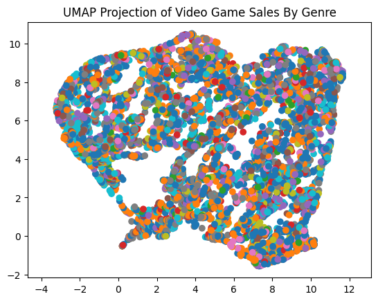

```python
# Plot UMAP embedding
plt.scatter(
    embedding[:,0],
    embedding[:,1],
    color = [
        # Color code genre values
        sns.color_palette()[x % len(sns.color_palette())] for x in df["Genre"].map({
            y: i for i, y in enumerate(set(df["Genre"]))
        })
    ]
)
plt.gca().set_aspect('equal', 'datalim')
plt.title("UMAP Projection of Video Game Sales By Genre")

plt.show()
```

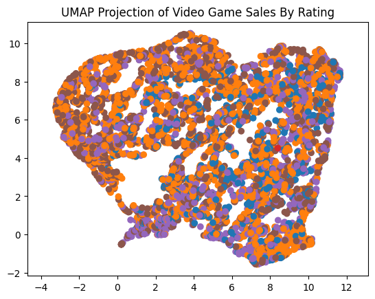

```python
# Plot UMAP embedding
plt.scatter(
    embedding[:,0],
    embedding[:,1],
    color = [
        # Color code rating values
        sns.color_palette()[x % len(sns.color_palette())] for x in df["Rating"].map({
            y: i for i, y in enumerate(set(df["Rating"]))
        })
    ]
)
plt.gca().set_aspect('equal', 'datalim')
plt.title("UMAP Projection of Video Game Sales By Rating")

plt.show()
```

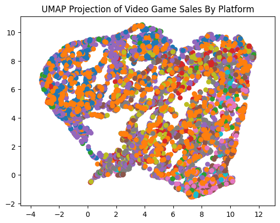

```python
plt.scatter(
    embedding[:,0],
    embedding[:,1],
    color = [
        # Color code platform values
        sns.color_palette()[x % len(sns.color_palette())] for x in df["Platform"].map({
            y: i for i, y in enumerate(set(df["Platform"]))
        })
    ]
)
plt.gca().set_aspect('equal', 'datalim')
plt.title("UMAP Projection of Video Game Sales By Platform")

plt.show()
```

Attempting to color code a UMAP representation of this data set by genre, rating, and platform in the above plots shows that there are no significant clusters by these features.